# 4. Duration and Convexity

## Overview

- Duration is an important concept that helps us to compute, quickly and approximately, how much the price of a bond should change in response to the yield change
  - Expressed in years, but it’s not the same as time to maturity
  - A sensitivity measure
    - High duration: bond price sensitive to interest rate changes
    - Low duration: insensitive, bond price stable
- Duration also summarizes a portfolio of bonds to one number, making it easy to hedge

## Bond Pricing Review

- (Time $t=0$ price of) zero coupon bond: $P(0, T) = e^{-T\times R(0, T)}$
- Write in a simplified notation: $$ B = e^{-TR} $$
- Zero coupon bond with notional $\mathcal N$: $$ B = \mathcal N e^{-TR} $$
- Non-zero coupon bond that pays a fixed coupon $c$ at times $\{T_1, T_2, \ldots, T_N\}$ and notional $\mathcal N$ at maturity $T_N$: $$ B = \mathcal N e^{-T_NR_N} + \sum_{j=1}^N c~e^{-T_j R_j}, $$ where $R_j = R(0, T_j)$
- Despite the seemingly involved notations, it's simply sum of discounted future cash flows

## Bond Pricing Review (Cont.)

\begin{align*} B &= \mathcal N e^{-T_NR_N} + \sum_{j=1}^N c~e^{-T_j R_j} \\ &= c~e^{-T_1 R_1} + c~e^{-T_2 R_2} + \cdots + c~e^{-T_N R_N} + \mathcal N e^{-T_NR_N} \end{align*}

- Example from previous set's Bond Pricing: Exercise I: $$ 2.5 e^{-0.5\times 0.0385} + 2.5 e^{-1\times 0.0365} + 2.5 e^{-1.5\times 0.0358} + 102.5 e^{-2\times 0.0351} = \$102.78 $$
- Here we have notional $\mathcal N = 100$ and
  - $c = 2.5$,
  - $T_1 = 0.5$, $R_1 = 3.85\%$,
  - $T_2 = 1.0$, $R_2 = 3.65\%$,
  - $T_3 = 1.5$, $R_3 = 3.58\%$
  - $B = 102.78$

## Sensitivity of ZCB Price to Its Yield Change

- Imagine, in a small period of time, the yield changes from $R$ to $R+\Delta$ for some small $\Delta$. The ZCB price before and after the yield change are respectively $$ B(0) = e^{-TR} \quad\text{and}\quad B(\Delta) = e^{-T(R+\Delta)} $$
- We are treating $B$ as a function of the yield change $\Delta$. Now find its first derivative at $\Delta = 0$: \begin{align*} &B'(0) = -Te^{-TR} \approx \frac{B(\Delta) - B(0)}{\Delta} \\ \iff& -TB(0) \approx \frac{B(\Delta) - B(0)}{\Delta} \\ \iff& -T\Delta \approx \frac{B(\Delta) - B(0)}{B(0)} \end{align*}
- Right hand side: percentage change of the ZCB price
- Left hand side: Term times yield change in the opposite direction
- Hence the negative sign
- In the case of ZCB, the term $T$ is the sensitivivity and is called the (Macaulay) duration of this ZCB

## ZCB Duration Example

$$ -T\Delta \approx \frac{B(\Delta) - B(0)}{B(0)} $$

- Duration of a ZCB is its term $T$
- On a day when the yield drops $0.06\% = 6\text{ bps}$ across the entire curve, we have
  - 1Y ZCB price up $0.06\% = 0.06\% \times 1$
  - 5Y ZCB price up $0.3\% = 0.06\% \times 5$
  - 10Y ZCB price up $0.6\% = 0.06\% \times 10$
  - 30Y ZCB price up $1.8\% = 0.06\% \times 30$
- The longer-term the bond is, the more sensitive it is to the yield change
  - This is true for nonzero coupon bonds too, as we will see soon
- $1\text{ bp}$ (basis point) is $0.01\%$, a common unit of measurement in the rates market
- Does the yield change by the same amount across the entire curve?
  - Yes, more or less, most of the time, as we will see when we get to Principal Component Analysis (PCA)
  - Yield changing by the same amount across the entire curve is so common it has a name "parallel shift of the curve"

## Sensitivity of Coupon Bond Price to Yield Change

- We repeat the same exercise but for coupon bonds
- Imagine, in a small period of time, the yields at all tenors change from $R_j$ to $R_j+\Delta$ for the same small amount $\Delta$. The bond price before and after the yield change are respectively \begin{align*} B(0) &= \mathcal N e^{-T_NR_N} + \sum_{j=1}^N c~e^{-T_j R_j} \\ &= c~e^{-T_1 R_1} + c~e^{-T_2 R_2} + \cdots + c~e^{-T_N R_N} + \mathcal N e^{-T_NR_N} \end{align*} and \begin{align*} B(\Delta) &= \mathcal N e^{-T_N(R_N + \Delta)} + \sum_{j=1}^N c~e^{-T_j (R_j + \Delta)} \\ &= c~e^{-T_1 (R_1 + \Delta)} + c~e^{-T_2 (R_2 + \Delta)} + \cdots + c~e^{-T_N (R_N + \Delta)} + \mathcal N e^{-T_N(R_N + \Delta)} \end{align*}
- Next we find the first derivative of $B(\Delta)$ at $\Delta = 0$

## Sensitivity of Coupon Bond Price to Yield Change (Cont.)

\begin{align*} B(0) &= c~e^{-T_1 R_1} + c~e^{-T_2 R_2} + \cdots + c~e^{-T_N R_N} + \mathcal N e^{-T_NR_N}, \\ B(\Delta) &= c~e^{-T_1 (R_1 + \Delta)} + c~e^{-T_2 (R_2 + \Delta)} + \cdots + c~e^{-T_N (R_N + \Delta)} + \mathcal N e^{-T_N(R_N + \Delta)}, \end{align*}

- We find the first derivative of $B(\Delta)$ at $\Delta = 0$ to be \begin{align*} B'(0) &= {\color{red}-\color{red}T_1}c~e^{-T_1 R_1} {\color{red}-\color{red}T_2} c~e^{-T_2 R_2} - \cdots {\color{red}-\color{red}T_N} c~e^{-T_N R_N} {\color{red}-\color{red}T_N} \mathcal N e^{-T_N R_N} \approx \frac{B(\Delta) - B(0)}{\Delta} \end{align*}
- To obtain the percentage change of bond price, multiply by $\Delta/B(0)$ on both sides: \begin{align*} {\color{red}-}\left(\frac{{\color{red}T_1}c~e^{-T_1 R_1} + {\color{red}T_2} c~e^{-T_2 R_2} + \cdots + {\color{red}T_N} c~e^{-T_N R_N} + {\color{red}T_N} \mathcal N e^{-T_N R_N}}{B(0)}\right)\Delta \approx \frac{B(\Delta) - B(0)}{B(0)} \end{align*}
- The quantity in the parentheses is the duration, denoted by $D$ hereafter, but it can be further simplified

## Duration of Coupon Bond

- Yield change $\Delta$ and percentage change of the bond price has the relation \begin{align*} -D\Delta \approx \frac{B(\Delta) - B(0)}{B(0)} \end{align*} where $D$ is the duration
- Again a negative sign because left hand side is yield change which right hand side is bond price change

## Duration of Coupon Bond (Cont.)

\begin{align*} B(0) = c~e^{-T_1 R_1} + c~e^{-T_1 R_1} + \cdots + c~e^{-T_N R_N} + \mathcal N e^{-T_NR_N} \end{align*}

- Yield change $\Delta$ and percentage change of the bond price has the relation \begin{align*} -D\Delta \approx \frac{B(\Delta) - B(0)}{B(0)}, \end{align*} where the duration $D$ is $$ D = \frac{{\color{red}T_1}c~e^{-T_1 R_1} + {\color{red}T_2} c~e^{-T_2 R_2} + \cdots + {\color{red}T_N} c~e^{-T_N R_N} + {\color{red}T_N} \mathcal N e^{-T_N R_N}}{B(0)} $$

$$ = T_1 w_1 + T_2 w_2 + \cdots + T_N w_N + T_N w_N^*, $$ where \begin{align*} w_j = \frac{c~e^{-T_jR_j}}{B(0)}, \quad\forall j=1, 2, \ldots, N, \quad\text{ and }\quad w_N^* = \frac{\mathcal Ne^{-T_NR_N}}{B(0)}, \end{align*} which satisfy $w_1 + w_2 + \cdots + w_N + w_N^* = 1$

## Duration: Properties & Implications

\begin{align*} -D\Delta \approx \frac{B(\Delta) - B(0)}{B(0)}, \end{align*}

- The duration $D = T_1 w_1 + T_2 w_2 + \cdots + T_N w_N + T_N w_N^*,$ where \begin{align*} w_j = \frac{c~e^{-T_jR_j}}{B(0)}, \quad\forall j=1, 2, \ldots, N, \quad\text{ and }\quad w_N^* = \frac{\mathcal Ne^{-T_NR_N}}{B(0)}, \end{align*} which satisfy $w_1 + w_2 + \cdots + w_N + w_N^* = 1$
- Duration is a weighted average of all payment dates (the terms)
- Recall that fair price of a bond is sum of all cash flows discounted
- Weights of duration are percentages of each discounted cash flow in the bond price
- In the case of ZCB $(c = 0)$, this formula reduces to $D=T_N$, consistent with previous result

## Duration: Properties & Implications (Cont.)

\begin{align*} -D\Delta \approx \frac{B(\Delta) - B(0)}{B(0)}, \end{align*}

- The duration $D = T_1 w_1 + T_2 w_2 + \cdots + T_N w_N + T_N w_N^*,$ where \begin{align*} w_j = \frac{c~e^{-T_jR_j}}{B(0)}, \quad\forall j=1, 2, \ldots, N, \quad\text{ and }\quad w_N^* = \frac{\mathcal Ne^{-T_NR_N}}{B(0)}, \end{align*} which satisfy $w_1 + w_2 + \cdots + w_N + w_N^* = 1$
- Duration is a weighted average of all payment dates (the terms)
- Since $w_N^* \gg w_j,$ the duration is still somewhat close to the bond's term $T_N$
- Previous conclusion "the longer the bond is, the more sensitive it is to yield change" is still valid
- Since $T_1 < T_2 < \cdots < T_N$, we know $D$ being a weighted average means $D \le T_N$
  - Coupons pulls the duration of a bond lower
  - The higher the coupon rate is, the lower the duration ($w_j$'s larger)

## Duration of Coupon Bond: Example

- Example from previous set's Bond Pricing: Exercise I: \begin{align*} B &= c~e^{-T_1 R_1} + c~e^{-T_2 R_2} + \cdots + c~e^{-T_N R_N} + \mathcal N e^{-T_NR_N}\\\\ \$102.78 &= 2.5 e^{-0.5\times 0.0385} + 2.5 e^{-1\times 0.0365} + 2.5 e^{-1.5\times 0.0358} + 102.5 e^{-2\times 0.0351} \end{align*}
- Duration is \begin{align*} D &= \left(T_1 c~e^{-T_1 R_1} + T_2 c~e^{-T_2 R_2} + \cdots + T_N c~e^{-T_N R_N} + T_N \mathcal N e^{-T_NR_N}\right)/B \end{align*} \begin{align*} &= \left(0.5\times 2.5 e^{-0.5\times 0.0385} + 1\times 2.5 e^{-1\times 0.0365} + 1.5\times 2.5 e^{-1.5\times 0.0358} + 2\times 102.5 e^{-2\times 0.0351}\right)/102.78 = 1.9293 \text{ (years)} \end{align*}
- If, today, the treasury yield is down 2 bps across the entire yield curve, the price of this bond will be up approximately $0.02\%\times 1.9293 = 0.039\%$
- If, today, the treasury yield is down 2 bps only for all tenors $\le$ 2y, the bond price will still be up $0.039\%$. (Why?)

## Duration of Coupon Bond: Example (Cont.)

- $D = 1.9293$ is close to but shorter than the term 2y
- The weights are \begin{align*} w_1 &= 2.5 e^{-0.5\times 0.0385}/102.78 = 0.02386,\\ w_2 &= 2.5 e^{-1\times 0.0365}/102.78 = 0.02345,\\ w_3 &= 2.5 e^{-1.5\times 0.0358}/102.78 = 0.02305,\\ w_4 &= 2.5 e^{-2\times 0.0351}/102.78 = 0.02267,\\ w_4^* &= 100 e^{-2\times 0.0351}/102.78 = 0.90699 \end{align*}
- $w_4^* \gg w_1 > w_2 > w_3 > w_4$

## Duration of Coupon Bond: Exercise

- Example from previous set's Bond Pricing: Exercise II: \begin{align*} B &= c~e^{-T_1 R_1} + c~e^{-T_2 R_2} + \cdots + c~e^{-T_N R_N} + \mathcal N e^{-T_NR_N}\\\\ \$100.56 &= 2 e^{-0.5\times 0.0385} + 2 e^{-1\times 0.0365} + 102 e^{-1.5\times 0.0358} \end{align*}
- What's its duration?
- If, today, the treasury yield is up 5 bps across the entire yield curve, what's the percentage change of the bond price?

## Dollar Duration

- Recall that, with the Macaulay duration $D$, we have $$ -D \Delta \approx \frac{B(\Delta) - B(0)}{B(0)} $$
- The $\Delta$ on the left hand side is the **absolute change** of the yield, while the right hand side is the **percentage change** of the bond price
- To make the right hand side absolute change of the price too, multiply through by $B(0)$ and define the dollar duration $$ D^{\$} = DB(0) $$
- We then obtain $$ -D^{\$} \Delta \approx B(\Delta) - B(0) $$
- It will be clear just a bit later why sometimes absolute changes are preferred

## DV01

- A related sensitivity measure is DV01, the dollar value of 1 bp, also known as PV01, the present value of 1 bp
- DV01 is the price change from a +1 bp paralle yield curve shift
- For a bond, plugging $\Delta = 1 \text{bp} = 10^{-4}$ into $-D^{\$} \Delta \approx B(\Delta) - B(0)$, we have $$ \text{DV01} = -D^{\$}\times 10^{-4} \approx B(\Delta) - B(0) $$

## Duration of a Bond Portfolio

- We repeat the same exercise for a portfolio of bonds
- If I hold $M$ bonds whose prices are \begin{align*} B_1 &= c_1e^{-T_1 R_1} + c_1e^{-T_2 R_2} + \cdots + c_1e^{-T_N R_N} + \mathcal N_1 e^{-T_{N_1}R_{N_1}}, \\ B_2 &= c_2e^{-T_1 R_1} + c_2e^{-T_2 R_2} + \cdots + c_2e^{-T_N R_N} + \mathcal N_2 e^{-T_{N_2}R_{N_2}}, \\ % B_3 &= c_3e^{-T_1 R_1} + c_3e^{-T_2 R_2} + \cdots + c_3e^{-T_N R_N} + \mathcal N_3 e^{-T_{N_3}R_{N_3}}, \\ &\qquad\qquad\qquad\qquad\qquad\qquad\vdots\\ B_M &= c_Me^{-T_1 R_1} + c_Me^{-T_2 R_2} + \cdots + c_Me^{-T_N R_N} + \mathcal N_M e^{-T_{N_M}R_{N_M}}, \\ \end{align*} which sum up to be the portfolio value $P = \sum_{j=0}^M B_j$
- If, in a small period of time, the yields at all tenors change from $R_j$ to $R_j+\Delta$ for the same small amount $\Delta$. The bond prices become \begin{align*} B_1(\Delta) &= c_1e^{-T_1 (R_1 + \Delta)} + c_1e^{-T_2 (R_2 + \Delta)} + \cdots + c_1e^{-T_{N_1} (R_{N_1} + \Delta)} + \mathcal N_1 e^{-T_{N_1}(R_{N_1} + \Delta)},\\ B_2(\Delta) &= c_2e^{-T_1 (R_1 + \Delta)} + c_2e^{-T_2 (R_2 + \Delta)} + \cdots + c_2e^{-T_{N_2} (R_{N_2} + \Delta)} + \mathcal N_2 e^{-T_{N_2}(R_{N_2} + \Delta)}, \\ &\qquad\qquad\qquad\qquad\qquad\qquad\vdots\\ B_M(\Delta) &= c_Me^{-T_1 (R_1 + \Delta)} + c_Me^{-T_2 (R_2 + \Delta)} + \cdots + c_Me^{-T_{N_M} (R_{N_M} + \Delta)} + \mathcal N_M e^{-T_{N_M}(R_{N_M} + \Delta)}, \end{align*} which sum up to be the portfolio value $P(\Delta) = \sum_{j=0}^M B_j(\Delta)$

## Duration of a Bond Portfolio (Cont.)

- Find the first derivative of $P(\Delta)$ at $\Delta=0$: \begin{align*} P'(0) =& \sum_{j=0}^M B_j'(0)\approx\frac{P(\Delta) - P(0)}{\Delta}\\ =& -T_1c_1e^{-T_1 R_1} -T_2 c_1e^{-T_2 R_2} - \cdots -T_{N_1} c_1e^{-T_{N_1} R_{N_1}} -T_{N_1} \mathcal N_1 e^{-T_{N_1}R_{N_1}} \\ &-T_1 c_2e^{-T_1 R_1} -T_2 c_2e^{-T_2 R_2} - \cdots -T_{N_2} c_2e^{-T_{N_2} R_{N_2}} -T_{N_2} \mathcal N_2 e^{-T_{N_2}R_{N_2}} \\ &\qquad\qquad\qquad\qquad\qquad\qquad\vdots\\ &- T_1 c_Me^{-T_1 R_1} -T_2 c_Me^{-T_2 R_2} - \cdots -T_N c_Me^{-T_N R_N} -T_{N_M} \mathcal N_M e^{-T_{N_M}R_{N_M}} \end{align*}
- Multiply by $\Delta/P(0)$ on both side to get \begin{align*} -\Delta&\left[\left(T_1c_1e^{-T_1 R_1} + T_2 c_1e^{-T_2 R_2} + \cdots + T_{N_1} c_1e^{-T_{N_1} R_{N_1}} + T_{N_1} \mathcal N_1 e^{-T_{N_1}R_{N_1}} \right.\right.\\ &+T_1 c_2e^{-T_1 R_1} + T_2 c_2e^{-T_2 R_2} + \cdots + T_{N_2} c_2e^{-T_{N_2} R_{N_2}} + T_{N_2} \mathcal N_2 e^{-T_{N_2}R_{N_2}} \\ &\qquad\qquad\qquad\qquad\qquad\qquad\vdots\\ &\left.\left. +T_1 c_Me^{-T_1 R_1} + T_2 c_Me^{-T_2 R_2} + \cdots + T_N c_Me^{-T_N R_N} +T_{N_M} \mathcal N_M e^{-T_{N_M}R_{N_M}}\right)/P(0)\right] \approx \frac{P(\Delta) - P(0)}{P(0)} \end{align*}

## Duration of a Bond Portfolio (Cont..)

\begin{align*} -\Delta&\left[\left(T_1c_1e^{-T_1 R_1} + T_2 c_1e^{-T_2 R_2} + \cdots + T_{N_1} c_1e^{-T_{N_1} R_{N_1}} + T_{N_1} \mathcal N_1 e^{-T_{N_1}R_{N_1}} \right.\right.\\ &+T_1 c_2e^{-T_1 R_1} + T_2 c_2e^{-T_2 R_2} + \cdots + T_{N_2} c_2e^{-T_{N_2} R_{N_2}} + T_{N_2} \mathcal N_2 e^{-T_{N_2}R_{N_2}} \\ &\qquad\qquad\qquad\qquad\qquad\qquad\vdots\\ &\left.\left. +T_1 c_Me^{-T_1 R_1} + T_2 c_Me^{-T_2 R_2} + \cdots + T_N c_Me^{-T_N R_N} +T_{N_M} \mathcal N_M e^{-T_{N_M}R_{N_M}}\right)/P(0)\right] \\&\approx \frac{P(\Delta) - P(0)}{P(0)} \end{align*}

- The quantity in the square brackets is the duration $D$ of the portfolio, and again we write \begin{align*} -\Delta D\approx \frac{P(\Delta) - P(0)}{P(0)} \end{align*}
- Since, all $c_i e^{-T_jR_j}$ and $\mathcal N_i e^{-T_{N_i}R_{N_i}}$ terms sum up to be the portfolio value $P(0)$, the duration $D$ is again a weighted average of all payment dates (terms) of future cash flows, with weights the corresponding discounted cash flows

## Portfolio Duration: Properties & Implications

- In general, the duration of a portfolio of future cash flows is the weighted average of all payment dates, with weights the corresponding discounted cash flows
- Like the coupon bond case, since $\mathcal N_i e^{-T_{N_i}R_{N_i}} \gg c_i e^{-T_jR_j}$, portfolio duration is somewhat close to a weighted average of the terms of the bonds in the portfolio
- But coupon pulls the duration lower, and again the higher the coupon rate is, the lower the duration

## Portfolio Dollar Duration

- The portfolio version of dollar duration is defined as $$ D^{\$} = DP(0) $$ and we have $$ -D^{\$} \Delta \approx P(\Delta) - P(0) $$
- This is saying, for small parallel shift of the curve, the value change of a portfolio is approximately equal to its dollar duration times the yield change, but in the opposite direction

## Hedging by Duration

- You can hedge a portfolio of bonds by making its dollar duration 0
- If you want to hedge a portfolio of bonds with dollar duration $D^{\$}$, add (buy or short sell) one more bond to it with dollar duration $-D^{\$}$
- Adding this one trade to the book, the entire portfolio will now have zero dollar duration and hence $$ P(\Delta) - P(0) \approx -D^{\$}\Delta = 0 $$
- Why are we matching the dollar duration, not the duration?

## Cost of Hedging

$$ $$

$$ D^{\$} = DB(0) $$

$$ $$

- We have a set amount for $-D^{\$}$, but should we go high on $D$ or $B(0)$?

## Hedging by Duration (Cont.)

- Adding one trade to the book, your portfolio now has zero dollar duration and is immune to small parallel shifts in the yield curve: $$ P(\Delta) - P(0) \approx -D^{\$}\Delta = 0 $$
- It is still exposed to shifts that are either large or nonparallel. How to hedge those?
  - Large parallel shift: By convexity
  - Nonparallel shift: By PCA

## Treasury ETFs

- [etfdb.com](https://etfdb.com/)'s screener is a convenient tool to look up exchange-traded funds (ETFs)
- Treasury ETFs can be found in: [etfdb.com](https://etfdb.com/) > ETF Screener > Asset Class > Bonds > Treasuries

$$ $$

| Ticker | Fund | Duration (yrs) |
| --- | --- | --- |
| SGOV | iShares 0-3 Month Treasury Bond ETF | 0.10 |
| SHY | iShares 1-3 Year Treasury Bond ETF | 1.85 |
| IEI | iShares 3-7 Year Treasury Bond ETF | 4.28 |
| IEF | iShares 7-10 Year Treasury Bond ETF | 7.05 |
| TLH | iShares 10-20 Year Treasury Bond ETF | 12.16 |
| TLT | iShares 20+ Year Treasury Bond ETF | 15.72 |

$$ $$

- Each ETF will have their own product page with all details, expense ratio, duration (for bond ETFs), holdings and more
- Long term Treasury bonds market data can be downloaded from: [TLT product page](https://www.ishares.com/us/products/239454/ishares-20-year-treasury-bond-etf) > Holdings > Detailed Holdings and Analytics

## Duration of TLT: Example

- From 9/17 to 9/18 close, treasury yield [was up 6 bps](https://home.treasury.gov/resource-center/data-chart-center/interest-rates/TextView?type=daily_treasury_yield_curve&field_tdr_date_value=202509)
  - Search "treasury yield today" to find this link
- Form 9/17 to 9/18 close, TLT price [dropped from 90.12 to 89.19](https://finance.yahoo.com/quote/TLT/history/), or down $1.03\%$
  - Search TLT on [finance.yahoo.com](https://finance.yahoo.com/) > click Historical Data on the left $$ 0.06\%\times 15.72 = 0.9432\% $$

## Duration and Volatility

\begin{align*} -D\Delta \approx \frac{B(\Delta) - B(0)}{B(0)} \end{align*}

- Short duration means bond price is stable; It does not change much no matter how much the yield curve moves
  - An extreme example, the price of a bond maturing tomorrow (duration 1/365) should be very close to the notional principal, no matter how the market moves
- Longer duration means bond price is more sensitive to yield change, so

$$ $$

$$ \text{Long Duration} = \text{Volatile Bond Price} $$

## Duration and Volatility (Cont.)

$$ $$

$$ \text{Long Duration} = \text{Volatile Bond Price} $$

$$ $$

- Previous example, on a day when the yield drops $0.06\% = 6\text{ bps}$ across the entire curve:
  - 1Y duration bond price up $0.06\% = 0.06\% \times 1$
  - 5Y duration bond price up $0.3\% = 0.06\% \times 5$
  - 10Y duration bond price up $0.6\% = 0.06\% \times 10$
  - 30Y duration bond price up $1.8\% = 0.06\% \times 30$

## Backtest Portfolio

- [portfoliovisualizer.com](https://www.portfoliovisualizer.com/) > See all the Analytics Tools > Backtest Portfolio > Edit Portfolio

$$ $$

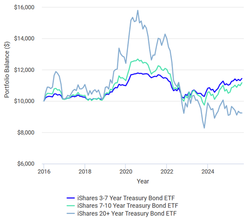

## Modified Duration

- So far we've derived the formulas under the assumption that the yield $R_j$'s are expressed with continuous compounding
- A different definition of the yield will lead to different formula
- Consider the below definition of yield $R$: \begin{align*} B = \mathcal N \left(1+\frac{R}{m}\right)^{-mT_N} + \sum_{j=1}^N c\left(1+\frac{R}{m}\right)^{-mT_j} \end{align*}
- Compared the above to the bond pricing formula \begin{align*} B = \mathcal N e^{-T_NR_N} + \sum_{j=1}^N c~e^{-T_j R_j}, \end{align*} in the new definition, the same yield $R$ is used for all terms, and it's expressed with a compounding frequency of $m$ times per year

## Modified Duration (Cont.)

- With this new definition of $R$, we have $$ -D^* \Delta = \frac{B(\Delta) - B(0)}{B(0)}, $$ where $$ D^* = \frac{D}{1+R/m}, $$ with $D$ the discounted cash flow weighted terms as before

## Modified Duration (Cont..)

- Given \begin{align*} B(\Delta) &= \mathcal N \left(1+\frac{R+\Delta}{m}\right)^{-mT_N} + \sum_{j=1}^N c\left(1+\frac{R+\Delta}{m}\right)^{-mT_j}, \end{align*} find the derivative $B'(0)$: \begin{align*} B'(0) &= \mathcal N \left(1+\frac{R}{m}\right)^{-mT_N}\left(-\frac{T_N}{1+\frac{R}{m}}\right) + \sum_{j=1}^N c\left(1+\frac{R}{m}\right)^{-mT_j}\left(-\frac{T_j}{1+\frac{R}{m}}\right)\\ &= -\left[{\color{red}T_N}\mathcal N \left(1+\frac{R}{m}\right)^{-mT_N} + \sum_{j=1}^N {\color{red}T_j} c\left(1+\frac{R}{m}\right)^{-mT_j}\right]/\left(1+\frac{R}{m}\right)\\ &\approx\frac{B(\Delta) - B(0)}{\Delta} \end{align*}

## Modified Duration (Cont...)

- We have \begin{align*} -\left[{\color{red}T_N}\mathcal N \left(1+\frac{R}{m}\right)^{-mT_N} + \sum_{j=1}^N {\color{red}T_j} c\left(1+\frac{R}{m}\right)^{-mT_j}\right]/\left(1+\frac{R}{m}\right) \approx\frac{B(\Delta) - B(0)}{\Delta} \end{align*}
- Multiply by $\Delta/B(0)$ on both sides to obtain \begin{align*} -\Delta\left[\frac{{\color{red}T_N}\mathcal N \left(1+\frac{R}{m}\right)^{-mT_N} + \sum_{j=1}^N {\color{red}T_j} c\left(1+\frac{R}{m}\right)^{-mT_j}}{\mathcal N \left(1+\frac{R}{m}\right)^{-mT_N} + \sum_{j=1}^N c\left(1+\frac{R}{m}\right)^{-mT_j}}\right]/\left(1+\frac{R}{m}\right) \approx\frac{B(\Delta) - B(0)}{B(0)}, \end{align*} where the quantity in the square brackets is $D$ and we've used the fact \begin{align*} B(0) = \mathcal N \left(1+\frac{R}{m}\right)^{-mT_N} + \sum_{j=1}^N c\left(1+\frac{R}{m}\right)^{-mT_j} \end{align*}

## Convexity of ZCB

- The approximation $$ -D \Delta \approx \frac{B(\Delta) - B(0)}{B(0)} $$ is only accurate when $\Delta$ is small. For large yield curve movement, we need 2nd order approximation
- Consider the ZCB case \begin{align*} B(\Delta) &= e^{-(R+\Delta)T} \approx B(0) + \Delta B'(0) + \frac{\Delta^2}{2} B''(0)\\ &= B(0) - T\Delta B(0) + T^2\frac{\Delta^2}{2} B(0) \end{align*}
- Divide through by $B(0)$ to obtain \begin{align*} \frac{B(\Delta) - B(0)}{B(0)} \approx - T\Delta + T^2\frac{\Delta^2}{2}\\ \end{align*}
- The 2nd term on the right hand side is an adjustment to the original approximation. $T^2$ is called the convexity, denoted by $C$ hereafter

## Convexity of Coupon Bond

- Taylor expansion of $B(\Delta)$ at $\Delta = 0$ gives $$ B(\Delta) \approx B(0) + \Delta B'(0) + \frac{\Delta^2}{2} B''(0), $$ so $$ \frac{B(\Delta) - B(0)}{B(0)} \approx \Delta \frac{B'(0)}{B(0)} + \frac{\Delta^2}{2} \frac{B''(0)}{B(0)} $$
- We will define $$ \frac{B'(0)}{B(0)} = -D, \qquad\frac{B''(0)}{B(0)} = C $$ and write $$ \frac{B(\Delta) - B(0)}{B(0)} \approx -D \Delta + \frac{1}{2}C\Delta^2 $$

## Convexity of Coupon Bond (Cont.)

$$ $$

$$ \frac{B(\Delta) - B(0)}{B(0)} \approx \Delta \frac{B'(0)}{B(0)} + \frac{\Delta^2}{2} \frac{B''(0)}{B(0)} $$

- We have \begin{align*} B(\Delta) &= \mathcal N e^{-T_N(R_N+\Delta)} + \sum_{j=1}^N c~e^{-T_j (R_j+\Delta)}, \\ \frac{B'(0)}{B(0)} &= -\frac{{\color{red}T_N}\mathcal N e^{-T_NR_N} + \sum_{j=1}^N {\color{red}T_j}c~e^{-T_j R_j}}{\mathcal N e^{-T_NR_N} + \sum_{j=1}^N c~e^{-T_j R_j}} = -D, \\ \frac{B''(0)}{B(0)} &= \frac{{\color{red}T_N^2}\mathcal N e^{-T_NR_N} + \sum_{j=1}^N {\color{red}T_j^2}c~e^{-T_j R_j}}{\mathcal N e^{-T_NR_N} + \sum_{j=1}^N c~e^{-T_j R_j}} = C \end{align*}

## Convexity: Properties & Implications

$$ $$

\begin{align*} D &= \frac{{\color{red}T_N}\mathcal N e^{-T_NR_N} + \sum_{j=1}^N {\color{red}T_j}c~e^{-T_j R_j}}{\mathcal N e^{-T_NR_N} + \sum_{j=1}^N c~e^{-T_j R_j}}, \\ C &= \frac{{\color{red}T_N^2}\mathcal N e^{-T_NR_N} + \sum_{j=1}^N {\color{red}T_j^2}c~e^{-T_j R_j}}{\mathcal N e^{-T_NR_N} + \sum_{j=1}^N c~e^{-T_j R_j}} \end{align*}

- Duration is a weighted average of all payment date terms
- Convexity is the weighted average of all payment date terms squared
- Same weights as duration
- Since $w_N^* \gg w_j,$ the duration is close to the bond's term squared: $T_N^2$
- For ZCB $(c=0)$, the convexity is equal to the term squared $T^2$
- Like duration, high coupon rate pulls convexity lower

## Dollar Convexity

- Recall that $$ \frac{B(\Delta) - B(0)}{B(0)} \approx -D \Delta + \frac{1}{2}C\Delta^2 $$
- One side is absolute change but the other is the percentage change
- Define the dollar duration and dollar convexity as $$ D^{\$} = DB(0), \qquad C^{\$} = CB(0), $$ respectively. We then obtain $$ B(\Delta) - B(0) \approx -D^{\$} \Delta + \frac{1}{2}C^{\$}\Delta^2 $$

## Portfolio Convexity and Portfolio Dollar Convexity

- The duration and convexity of a portfolio of $M$ bonds are \begin{align*} D &= \frac{\sum_{i=1}^M{\color{red}T_{N_M}}\mathcal N_M e^{-T_{N_M}R_{N_M}} + \sum_{i=1}^M\sum_{j=1}^N {\color{red}T_j}c_i~e^{-T_j R_j}}{\sum_{i=1}^M\mathcal N_M e^{-T_{N_M}R_{N_M}} + \sum_{i=1}^M\sum_{j=1}^N c_i~e^{-T_j R_j}}, \\ C &= \frac{\sum_{i=1}^M{\color{red}T_{N_M}^2}\mathcal N_M e^{-T_{N_M}R_{N_M}} + \sum_{i=1}^M\sum_{j=1}^N {\color{red}T_j^2}c_i~e^{-T_j R_j}}{\sum_{i=1}^M\mathcal N_M e^{-T_{N_M}R_{N_M}} + \sum_{i=1}^M\sum_{j=1}^N c_i~e^{-T_j R_j}}, \end{align*} respectively
- And its dollar duration and dollar convexity are defined as $$ D^{\$} = DP(0), \qquad C^{\$} = CP(0), $$ respectively
- We have $$ P(\Delta) - P(0) \approx -D^{\$} \Delta + \frac{1}{2}C^{\$}\Delta^2 $$

## Hedging by Duration and Convexity

- We have shown that, if you make a portfolio's dollar duration zero, it's immune to small parallel shifts in the yield curve
- To make it immune to large parallel shift, you need to make dollar convexity zero too, so that $$ P(\Delta) - P(0) \approx -D^{\$} \Delta + \frac{1}{2}C^{\$}\Delta^2 = 0 $$
- Suppose you are hedging a portfolio with dollar duration $D^{\$}_P$ and dollar convexity $C^{\$}_P$. If you could add a bond with dollar duration $-D^{\$}_P$ and dollar convexity $-C^{\$}_P$, you are done
- But in general this cannot be achieved by one single bond
- With two equations ($-D^{\$} = 0$ and $-C^{\$} = 0$) we need two variables

## Hedging by Duration and Convexity (Cont.)

- Suppose we have two bonds $B_1$ and $B_2$:
  - $B_1$ has dollar duration $D^{\$}_1$ and dollar convexity $C^{\$}_1$
  - $B_2$ has dollar duration $D^{\$}_2$ and dollar convexity $C^{\$}_2$
- Buy $h_1$ units of $B_1$ and $h_2$ units of $B_2$ so that \begin{align*} &h_1 D^{\$}_1 + h_2 D^{\$}_2 = -D^{\$}_P\\ &h_1 C^{\$}_1 + h_2 C^{\$}_2 = -C^{\$}_P \end{align*}
- Solve the system to obtain hedge ratio

## Linear Systems for Hedging

- It's not uncommon we need so solve a linear system to figure out the hedge ratio
- Steps to hedge
  1. Characterize factors (reasons) of the portfolio value change, in our example the $\Delta$ and $\Delta^2$
  2. Write portfolio value change in terms of the factor changes
  3. Find hedge (trades, in our example, bonds) and hedge ratio to make coefficients ($D$ and $C$ in our example) zero
- We will see linear system for hedging again in PCA

## Hedging by Duration and Convexity (Cont..)

- After all the hard work we have $$ P(\Delta) - P(0) \approx -D^{\$} \Delta + \frac{1}{2}C^{\$}\Delta^2 = 0 $$
- The portfolio is now immune to large parallel shifts in the yield curve
- But still exposed to nonparallel shifts, which can be hedged by PCA